# ML_Assignment1

2023-01-20

## Loading library

```r
library(tidyverse)
library(ggridges)
library(lmtest)
library(knitr)
library(kableExtra)

set.seed(1)
```

## Question 1:

#### Construct a table providing summaries of the quantitative features of the dataset.

```r
bcdata = read_csv(file = "./data/Assignment1_bcdata.csv")
bcdata = janitor::clean_names(bcdata)
```

```r
summarized_df = bcdata %>% rename (mcp1 = mcp_1) %>%
  select(-c(classification)) %>%
  summarise(across(everything(), list(mean=mean, median=median, min = min, max = max)))  %>%
   pivot_longer(age_mean:mcp1_max,
                 names_to = "Type",
                 values_to = "Value") %>%
  separate(Type, c('Quantitative features', 'Summaries')) %>%
  pivot_wider (names_from = "Summaries",
  values_from = "Value") %>%
knitr::kable (caption = "Summaries of the Quantitative Features", align = c ("c", "c"), digits = 2) %>%  kable_paper("striped", full_width = F) %>%
  column_spec(1, bold = T)


summarized_df
```

Summaries of the Quantitative Features

| Quantitative features | mean | median | min | max |
| --- | --- | --- | --- | --- |
| age | 57.30 | 56.00 | 24.00 | 89.00 |
| bmi | 27.58 | 27.66 | 18.37 | 38.58 |
| glucose | 97.79 | 92.00 | 60.00 | 201.00 |
| insulin | 10.01 | 5.92 | 2.43 | 58.46 |
| homa | 2.69 | 1.38 | 0.47 | 25.05 |
| leptin | 26.62 | 20.27 | 4.31 | 90.28 |
| adiponectin | 10.18 | 8.35 | 1.66 | 38.04 |
| resistin | 14.73 | 10.83 | 3.21 | 82.10 |
| mcp1 | 534.65 | 471.32 | 45.84 | 1698.44 |

*Comments: The table is summaries of the quantitative features. And their units are as follows: Age (years), BMI (kg/m2), Glucose (mg/dL), Insulin (μU/mL), HOMA-IR (), Leptin (ng/mL), Adiponectin (μg/mL), Resistin (ng/mL), MCP-1(pg/dL).*

## Question 2:

#### Recode BMI into the WHO-defined categories below

```r
Q2_df = bcdata %>% mutate(bmi_group =
                    case_when(bmi < 16.5 ~ 'Severely underweight',
                              bmi < 18.5 ~ "Underweight",
                              bmi <= 24.9 ~ "Normal weight",
                              bmi <= 29.9 ~"Overweight",
                              bmi <= 34.9 ~"Obesity class I",
                              bmi <= 39.9 ~"Obesity class II",
                              bmi >= 40~ "Obesity class III"))
  Q2_df
```

```
## # A tibble: 116 × 11
##      age   bmi glucose insulin  homa leptin adiponectin resistin mcp_1 classif…¹
##    <dbl> <dbl>   <dbl>   <dbl> <dbl>  <dbl>       <dbl>    <dbl> <dbl>     <dbl>
##  1    48  23.5      70    2.71 0.467   8.81        9.70     8.00  417.         1
##  2    83  20.7      92    3.12 0.707   8.84        5.43     4.06  469.         1
##  3    82  23.1      91    4.50 1.01   17.9        22.4      9.28  555.         1
##  4    68  21.4      77    3.23 0.613   9.88        7.17    12.8   928.         1
##  5    86  21.1      92    3.55 0.805   6.70        4.82    10.6   774.         1
##  6    49  22.9      92    3.23 0.732   6.83       13.7     10.3   530.         1
##  7    89  22.7      77    4.69 0.891   6.96        5.59    12.9  1256.         1
##  8    76  23.8     118    6.47 1.88    4.31       13.3      5.10  281.         1
##  9    73  22        97    3.35 0.802   4.47       10.4      6.28  137.         1
## 10    75  23        83    4.95 1.01   17.1        11.6      7.09  318.         1
## # … with 106 more rows, 1 more variable: bmi_group <chr>, and abbreviated
## #   variable name ¹classification
```

*Comments: The continuous variable `BMI` was transferred into a categorical variable `bmi_group` based on the WHO-defined categories. And there were only 5 categories*

## Question 3:

#### Create a bar chart showing the proportion of breast cancer cases and controls within each BMI category.

```r
Q3_cases = Q2_df %>% group_by(bmi_group) %>%
  filter(classification==2) %>%
  summarize(count = n()) %>%
  mutate(cases_no = count) %>% select(!count)

Q3_controls = Q2_df %>% group_by(bmi_group) %>%
  filter(classification==1) %>%
  summarize(count = n())  %>%
  mutate(controls_no = count) %>% select(!count)
```

```r
Q3_total=full_join(Q3_cases,Q3_controls, by=c("bmi_group"))

Q3_total[is.na(Q3_total)] = 0

Q3_total = Q3_total %>% mutate (total_no =cases_no + controls_no ) %>%
  mutate (cases_percent= (cases_no / total_no)*100,
          controls_percent = (controls_no / total_no)*100) %>%
  select(bmi_group, cases_percent, controls_percent) %>%
  mutate(bmi_group = fct_relevel(bmi_group, c("Underweight", "Normal weight",
                       "Overweight","Obesity class I","Obesity class II"))) %>%
   arrange(bmi_group) %>%
  pivot_longer(cases_percent:controls_percent,
                 names_to= "Type",
                 values_to = "Percent")
```

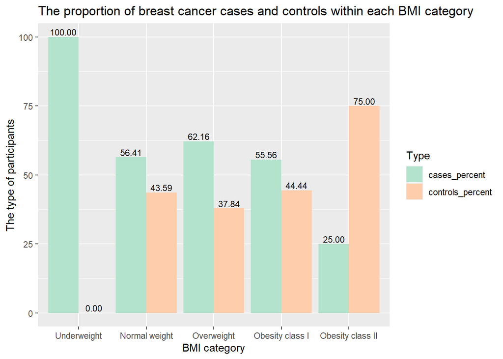

```r
bar_chart = Q3_total %>% ggplot(aes(x=bmi_group,y=Percent,fill=Type)) +
  geom_bar(stat="identity", position = "dodge") +
  scale_fill_brewer(palette = "Pastel2")+
 geom_text(aes(label=sprintf("%0.2f", Percent)), position=position_dodge(width=0.9), vjust=-0.25, size=3) +
  labs(title = "The proportion of breast cancer cases and controls within each BMI category", x = "BMI category", y = "The type of participants")

bar_chart
```

## Question 4:

#### Construct a logistic regression model using breast cancer classification as the outcome and glucose, HOMA-IR, leptin, BMI (continuous) and age as the independent variables.

```r
bcdata_df = bcdata %>% mutate(classification = recode_factor(classification,
                                                             "1"="0",
                                                             "2"="1"))
fit_logistic =
  glm(classification ~ glucose + homa + leptin + bmi + age, family=binomial(link="logit"), data = bcdata_df)
```

```r
fit_logistic %>%
  broom::tidy() %>%
   mutate(Lower_CI = (estimate -1.96*std.error),
         Upper_CI = (estimate +1.96*std.error)) %>%
  select(term, estimate,std.error, Lower_CI, Upper_CI, statistic, p.value) %>%
  kbl(caption     = "Effect of Selected Predictors on breat cancer classification"
    , col.names   = c("Predictors", "Beta Estimate","SE", "Lower bound of 95% CI","Upper bound of 95% CI", "t-statistic", "p-value"),
    digits= 2) %>%
 kable_paper("striped", full_width = F) %>%
  column_spec(1, bold = T)
```

Effect of Selected Predictors on breat cancer classification

| Predictors | Beta Estimate | SE | Lower bound of 95% CI | Upper bound of 95% CI | t-statistic | p-value |
| --- | --- | --- | --- | --- | --- | --- |
| (Intercept) | -3.63 | 2.36 | -8.24 | 0.99 | -1.54 | 0.12 |
| glucose | 0.08 | 0.02 | 0.04 | 0.13 | 3.47 | 0.00 |
| homa | 0.27 | 0.17 | -0.06 | 0.61 | 1.59 | 0.11 |
| leptin | -0.01 | 0.02 | -0.04 | 0.02 | -0.54 | 0.59 |
| bmi | -0.10 | 0.06 | -0.22 | 0.01 | -1.84 | 0.07 |
| age | -0.02 | 0.01 | -0.05 | 0.01 | -1.59 | 0.11 |

*Comments: With all the other variables held constant, if 1-unit changes in HOMA-IR, the beta estimate is 0.27 and its related 95% confidence interval from -0.06 to 0.61*

## Question 5:

#### Construct a linear regression model using insulin as the outcome and BMI (continuous), age, and glucose as the independent variables.

```r
fit_linear = lm (insulin ~ bmi + age + glucose, data = bcdata)
```

```r
fit_linear %>%
   summary() %>%
   broom::tidy() %>%
  mutate(Lower_CI = (estimate -1.96*std.error),
         Upper_CI = (estimate +1.96*std.error)) %>%
  select(term, estimate, std.error, Lower_CI, Upper_CI, statistic, p.value) %>%
  kbl(caption= "Effect of Selected Predictors on insulin level"
    , col.names   = c("Predictor", "Beta Estimate", "SE","Lower bound of 95% CI",
                      "Upper bound of 95% CI","t-statistic", "p-value"),
     digits= 6) %>%
  kable_paper("striped", full_width = F) %>%
  column_spec(1, bold = T)
```

Effect of Selected Predictors on insulin level

| Predictor | Beta Estimate | SE | Lower bound of 95% CI | Upper bound of 95% CI | t-statistic | p-value |
| --- | --- | --- | --- | --- | --- | --- |
| (Intercept) | -13.495759 | 5.859413 | -24.980209 | -2.011309 | -2.303261 | 0.023110 |
| bmi | 0.149690 | 0.163818 | -0.171393 | 0.470774 | 0.913759 | 0.362806 |
| age | -0.054022 | 0.051939 | -0.155822 | 0.047779 | -1.040099 | 0.300534 |
| glucose | 0.229818 | 0.037515 | 0.156288 | 0.303348 | 6.126000 | 0.000000 |

*Comments: With all the other variables held constant, if 1-unit changes in age, the beta estimate is -0.054 and its related 95% confidence interval from -0.156 to 0.048.*